# Envío de propuestas a conferencias globales de R

¿Qué barreras percibe la comunidad de América Latina? – Resultados de una encuesta sobre enviar propuestas de charlas a rstudio::global(2021)

## Objetivos de este informe y de la encuesta asociada

Muchas de las próximas conferencias globales de R serán virtuales. La posibilidad de participar a la distancia disminuye el presupuesto y el tiempo destinado a asistir y/o exponer en estas conferencias. Así, las próximas conferencias virtuales suponen una oportunidad de incluir presentaciones de asistentes usualmente relegados, aumentando la diversidad de las exposiciones.

En este marco, una primera experiencia para la comunidad de usuarias/os de R de América Latina fue el llamado a enviar propuestas de charlas a la conferencia rstudio::global(2021). En nuestra comunidad, nos alentamos a enviar propuestas y organizamos actividades y redes de cooperación para mejorar nuestros envíos. Para el envío de propuestas a esta conferencia, se solicitaba un título y resumen (abstract) en inglés, más un video de hasta 60 segundos también en inglés (más detalles aquí: https://blog.rstudio.com/2020/07/17/rstudio-global-call-for-talks/).

El **objetivo** de este informe es analizar qué ayudó y qué fue una barrera para la comunidad de usuarias/os de R en América Latina, a la hora de enviar una propuesta de charla a la conferencia rstudio::global(2021). Así, podremos proponer herramientas y mejoras en próximas conferencias virtuales y/o globales.

La **encuesta** se encontró abierta a recibir respuestas entre el 29 de agosto de 2020 (el día siguiente al plazo límite para envíos) y el 16 de septiembre de 2020. Estuvo destinada a la comunidad de usuarias/os de R en América Latina, en particular a quienes enviamos o pensamos en enviar propuestas de charlas a la conferencia rstudio::global(2021). La encuesta estaba escrita en castellano rioplatense. Se difundió en la comunidad de LatinR y en la red social Twitter.

La encuesta y este informe fueron elaborados por *Natalia Morandeira*, con aportes y colaboración de *Paola Corrales*, *Yanina Bellini Saibene* y *Elio Campitelli*.

## Respuestas recibidas

La encuesta fue respondida por **11 personas**, que enviaron un total de **12 propuestas de charlas** a rstudio::conf(2021). Conocemos que 2 de estas 12 charlas fueron aceptadas para su presentación en la conferencia. Esto no excluye la posibilidad de que haya otras propuestas enviadas y/o aceptadas con autoría de expositores de América Latina.

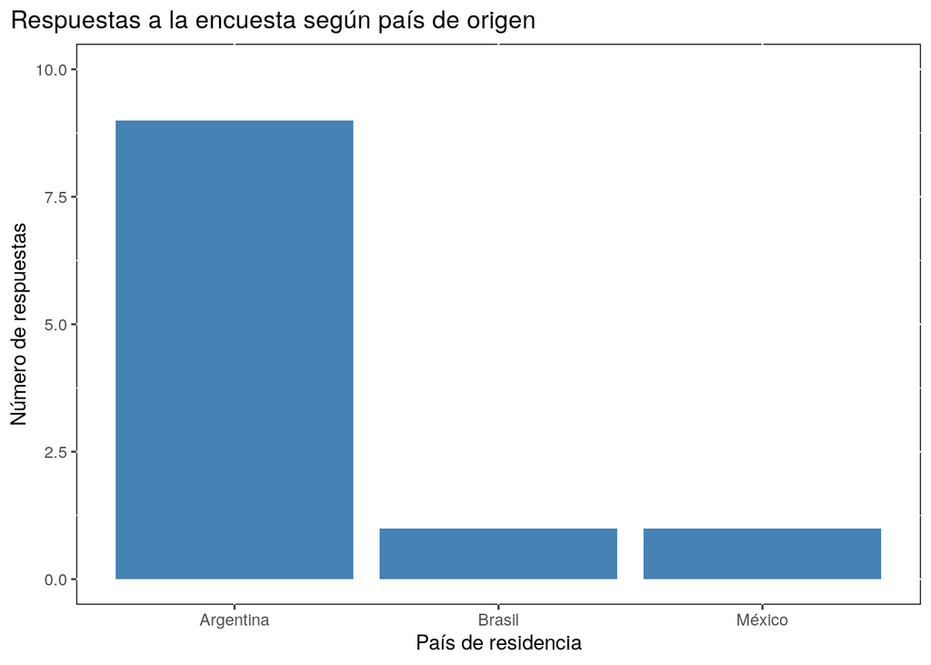

## Barreras percibidas para el envío de propuestas

La primera pregunta en relación a las dificultades o barreras percibidas fue: *“¿Cuáles fueron tus dificultades o barreras para enviar propuestas de charlas? (podés marcar todas las opciones que consideres necesarias)”* y las opciones fueron:

1. La temática.
2. El grado de avance del trabajo propuesto.
3. La falta de claridad en las instrucciones de la conferencia.
4. Redactar el título y abstract en inglés.
5. Grabar el video, debido al inglés.
6. Grabar el video, debido a la incomodidad en compartir mi imagen y/o voz.
7. Grabar el video, debido a una discapacidad visual o auditiva o debido a dificultades del habla o motrices, entre otras.
8. Grabar el video, debido a los recursos tecnológicos de que dispongo y/o mis habilidades con la técnica audiovisual.
9. Otra (¿cuál?).

Los resultados obtenidos se muestran en los siguientes dos gráficos. Cabe destacar que todas las personas que contestaron la encuesta enviaron una o dos propuestas de charlas. Es decir, **no recabamos información sobre las potenciales barreras a personas que no llegaron a enviar propuestas de charlas**.

La solicitud de enviar una propuesta de charla en formato video breve fue percibida como una dificultad o barrera por 9 de las 11 personas que contestaron a la encuesta (las cuales enviaron 10 charlas). Ocho de estas personas indicaron dificultades relacionadas con el envío del video en idioma inglés; mientras que 3 personas indicaron incomodidad en compartir su voz y/o imagen; y 3 personas indicaron dificultades debido a los recursos tecnológicos y/o habilidades audiovisuales de que disponen.

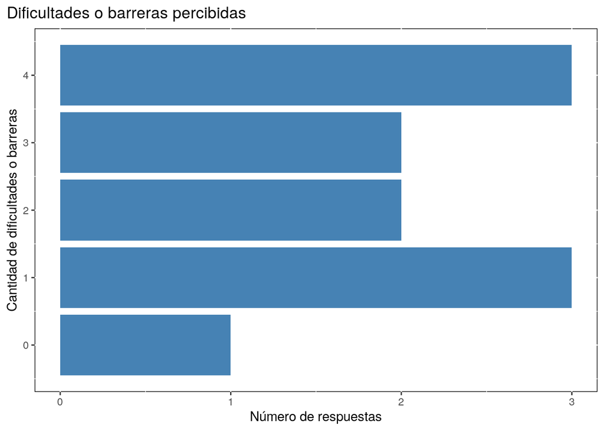

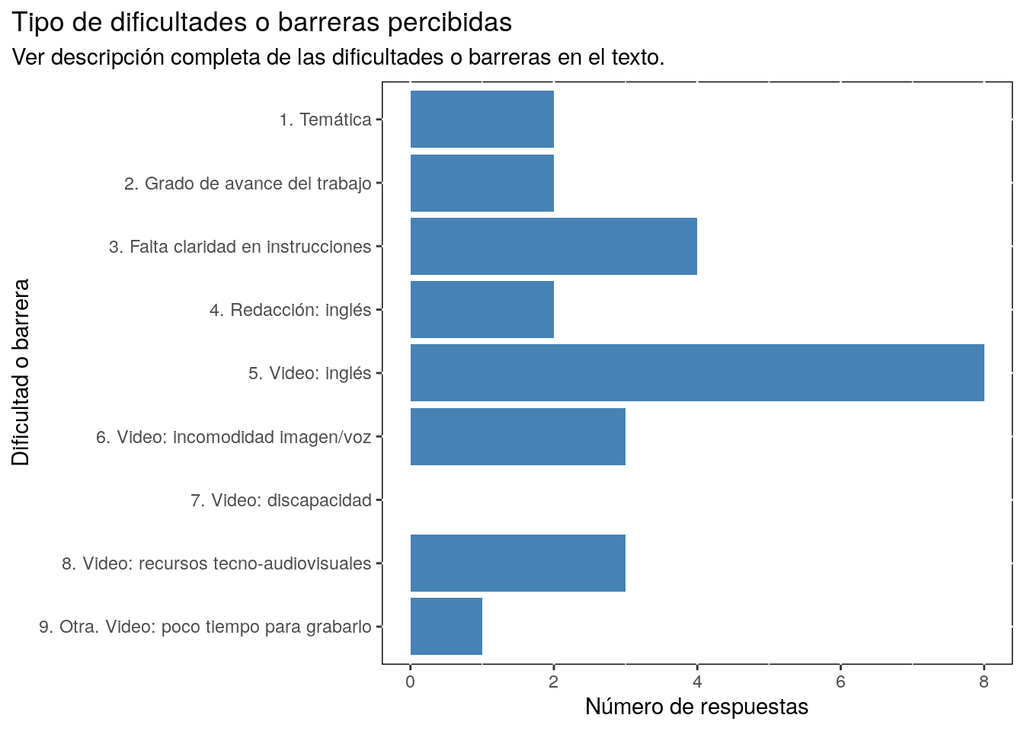

Las siguientes preguntas buscaron conocer cómo fue el proceso de redacción de título y resumen de la conferencia y cómo fue el proceso de elaboración del guión del video. En particular, apuntaron a conocer las posibles dificultades por no ser hablantes nativas/os de inglés. Las preguntas originales fueron:

*“En relación a la redacción del título-abstract, ¿con cuál de estas opciones te identificás más?”* y las opciones posibles fueron (selección excluyente):

1. Escribí en castellano/portugués y luego los traduje a inglés.
2. Escribí directamente en inglés, revisando la redacción en internet o con ayuda de otra persona.
3. Escribí directamente en inglés, no revisé mucho más que si lo hubiera escrito en castellano/portugués.
4. Otra.

Las opciones están ordenadas en orden decreciente de esfuerzo en comparación con el esfuerzo de una/un hablante nativa/o de inglés. No se recibieron respuestas *4. Otra*.

Diez de las personas indicaron opciones consistentes con un esfuerzo adicional respecto a una/un hablante nativa/o. De acuerdo a las respuestas a la pregunta anterior, la redacción en inglés fue percibida como una barrera para 2 de estas personas; mientras que las 8 restantes no lo señalaron como barrera (a pesar del esfuerzo adicional).

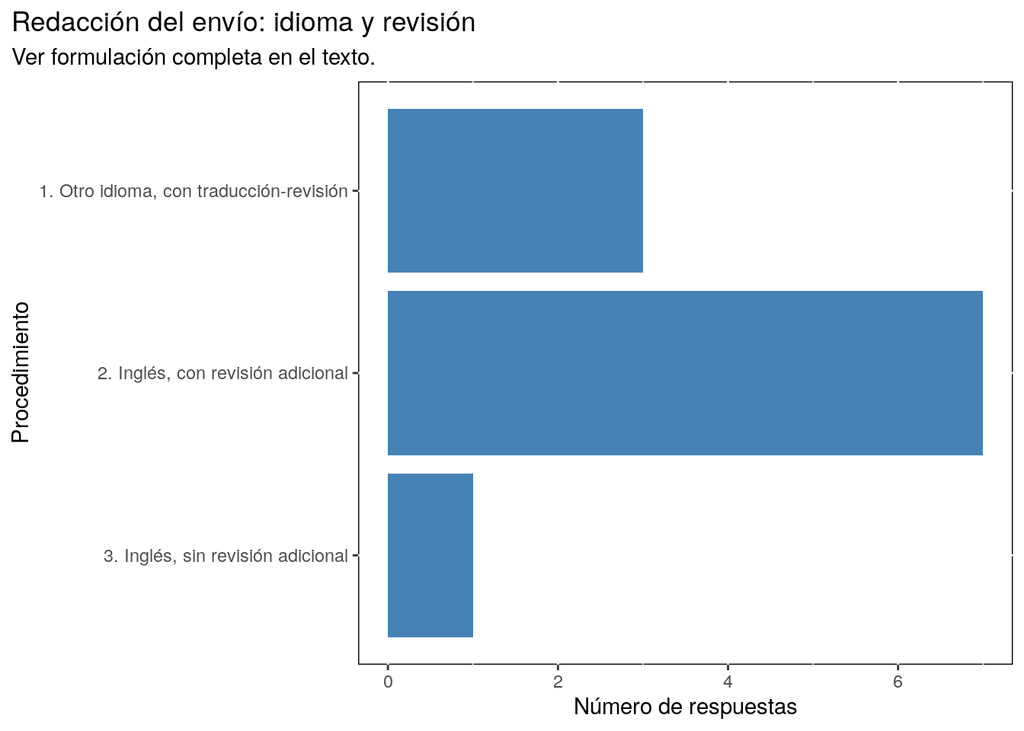

*En relación al guión del video, ¿con cuál de estas opciones te identificás más?* y las opciones posibles fueron (selección excluyente):

1. Escribí el guión del video en castellano/portugués y luego lo traduje al inglés.
2. Escribí el guión del video directamente en inglés, lo revisé y busqué pronunciaciones.
3. Escribí el guión del video directamente en inglés, no revisé ni practiqué más que si lo hubiera hecho en castellano/portugués.
4. No elaboré un guión pormenorizado para el video.

Las opciones están ordenadas en orden decreciente de esfuerzo en comparación con el esfuerzo de una/un hablante nativa/o de inglés. No se recibieron respuestas *3* ni *4*.

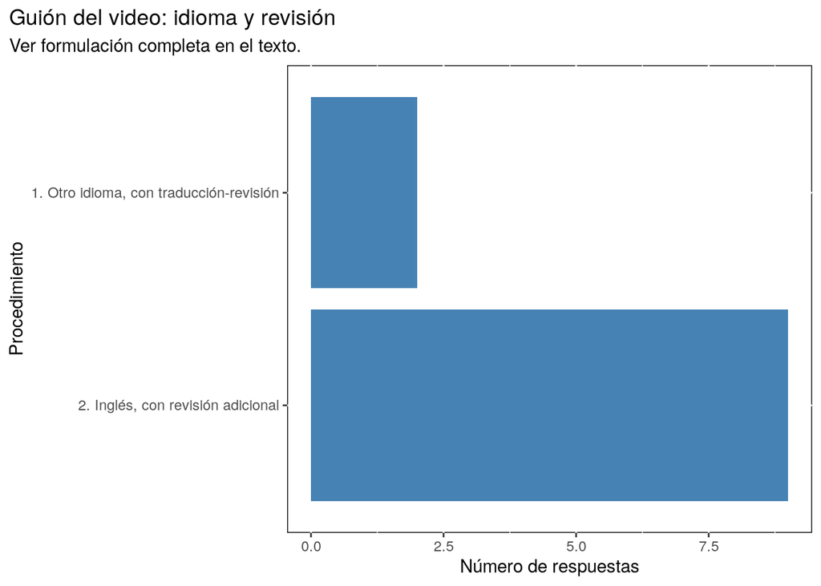

### Comentarios abiertos en relación a las dificultades y barreras

Se copian algunos de los comentarios dejados por quienes respondieron a la encuesta, ya sea en el apartado “sugerencias para mejorar próximas conferencias” o bien en el campo de comentarios abiertos.

- En relación al idioma: *“Que nos dejen presentar en nuestro idioma”* (dos personas incluyeron este comentario); *“Permitir charlas en otro idioma desde un principio”*; *“Flexibilidad con el idioma”*; *“Que el idioma de la presentación no sea un requisito”*; *“Poder enviar nuestros resumenes en inglés y en nuestra lengua nativa”*.
- En relación a idiomas/subtítulos: *“Que se invierta para hacer traducciones auditivas y subtítulos en la mayor cantidad de idiomas posibles”*; *“Incluir subtítulos”*; *“Que en las presentaciones orales grabadas estén disponibles los subtítulos en varios idiomas”*.
- En relación a los videos: *“No hacer una selección por video”*, *“Quitar el requisito de grabar el video. Genera un filtro innecesario a la hora de enviar trabajos y es posible que afecte negativamente la evaluación de los evaluadores. Esto iría en la misma dirección que las políticas en contra de poner fotos en curriculum vitae y de realizar evaluaciones ciegas en orquestas”*; *“Hacer algo que no seleccione por video (imagen, aspecto, idioma). Capaz grabar sólo mi voz hubiera sido menos intimidante que el video. Y además evaluar sólo la voz limita la discriminación (de los evaluadores) por imagen (identidad sexual, color de piel, vestuario, etc)”*; *“La possibilidad de hacer el video en mi lengua y poner subtitulos”.*
- *“Asignar un corrector/a de inglés gratuito para los abstract.”*
- *“Que publiquen las propuestas que reciben para aprender de ellas.”*

## Cooperación y ayuda

En esta segunda parte de la encuesta buscamos recabar posibles ayudas o alientos de la comunidad de América Latina.

La **#clinicadeCharlas** (en portugués: #clinicadePalestras) es espacio de la comunidad de LatinR. En el marco del envío de propuestas a rstudio::global(2021), se realizaron reuniones virtuales, se discutieron las instrucciones para el envío de trabajos, se recibió y dio feedback sobre resúmenes y videos en documentos de trabajo colaborativos, entre otras actividades. En el **canal de slack** #clinicadecharlas de LatinR se sumaron **45 personas** desde julio de 2020. La existencia del espacio se divulgó en las comunidades de LatinR, RLadies, RenBaires, entre otras, en idiomas castellano y portugués. El espacio sigue abierto para colaborar en el envío a otras conferencias.

En relación a esta iniciativa, se preguntó si se conocía la existencia de la #clinicadecharlas, si se había participado y cuán importante fue para el envío de propuestas de charlas a rstudio::global(2021).

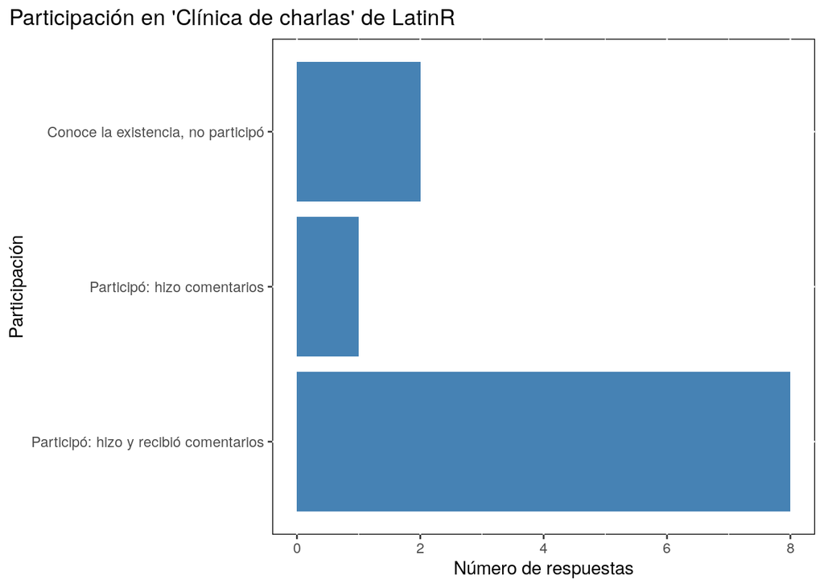

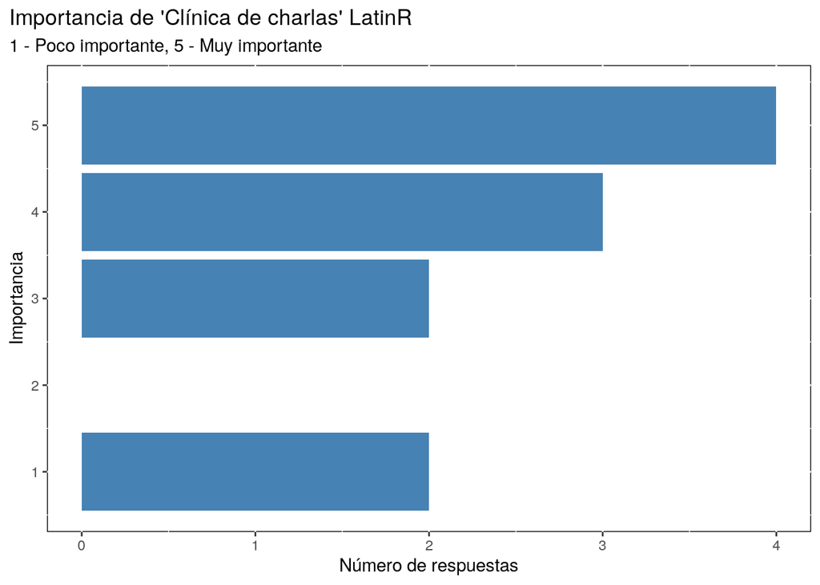

La charla de *Riva Quiroga* (**RLadies Chile + LatinR**) *“¿Cómo preparar una propuesta de presentación para una conferencia o un meetup de R?”* fue un MeetUp en el que Riva presentó consejos sobre cómo enfocar la propuesta y realizar un envío exitoso, con ejemplos de propuestas de usuarias de R de América Latina. La charla se realizó el día 1 de agosto de 2020 y luego estuvo disponible la grabación. En el MeetUp se inscribieron 68 personas. Más información aquí: https://www.meetup.com/rladies-scl/events/272107368/.

En relación a esta charla, se preguntó si se conocía la existencia de la charla, si se había asistido y cuán importante fue para el envío de propuestas de charlas a rstudio::global(2021).

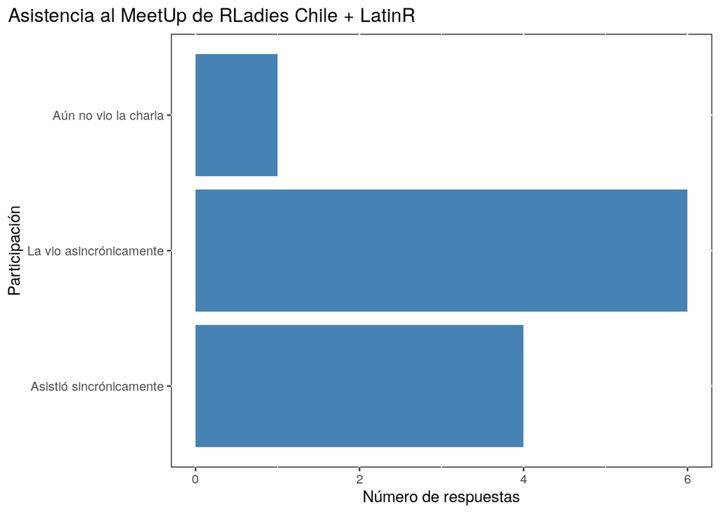

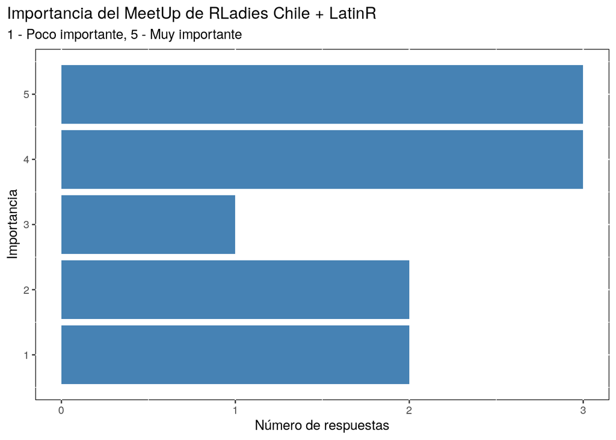

Finalmente, se consultó: **“En las próximas conferencias de R, ¿te interesaría o parecería relevante que haya herramientas similares?”**. Nueve de las 11 personas respondieron que sería interesante/relevante repetir ambas herramientas, 1 persona refirió sólo a la #clínicadecharlas y la persona restante refirió sólo a una charla del estilo de la de Riva Quiroga.

### Comentarios abiertos en relación a cooperación y ayuda

Se copian algunos de los comentarios dejados por quienes respondieron a la encuesta, que se relacionan con aspectos que contribuyen a enviar charlas.

- *“La clínica de charlas fue increíble!”*; *“Y la clínica es un proyecto colaborativo de la comunidad Latinoamericana.”*
- *“Riva Quiroga revisó y me ayudó un montón, su colaboración fue muy importante.”*
- *“Me parece muy interesante desde RStudioconf el entrenamiento gratuito para las charlas seleccionadas.”*